# Projet IF36 - Analyse des données de Kickstarter

L’objectif de ce projet d’IF36 est d’analyser et de présenter des données issues d’un jeu de données de notre choix.

## 👥 Membres

Équipe Civizualisation :

- Florian BONELLI
- Eyvan FAURE
- Ryan OUYED
- Lucas SAURON

## 📚 Sommaire

- 📝 Contexte des données choisis
- 📥 Téléchargement des données
- 📁 Présentation des données
- 📊 Plan d’analyse
- 🧭 Exploration des données

## 📝 Contexte des données choisis

[figure not shown]

Nous avons choisi d’utiliser les données du site de financement participatif Kickstarter.

Kickstarter offre l’opportunité à des créateurs de transformer des idées en réalité grâce au financement participatif.

Cette plateforme permet de lever des fonds pour financer des projets en mettant en relation des contributeurs du monde entier.

Nous avons décidé d’utiliser le jeu de données [Kickstarter Projects](https://www.kaggle.com/datasets/kemical/kickstarter-projects) disponible sur Kaggle.

Ces données sont collectées depuis la plateforme [Kickstarter](https://www.kickstarter.com/).

Ce projet nous permettra d’explorer les tendances du financement participatif, d’identifier les facteurs qui influencent le succès d’un projet et d’évaluer la probabilité de réussite des campagnes sur cette plateforme.

Nous chercherons également à visualiser ces données de manière claire et intuitive pour mieux comprendre les dynamiques du financement participatif.

## 📥 Téléchargement des données

Les données utilisées dans ce projet ne sont pas incluses dans ce dépôt en raison de leur taille.

Il faut les télécharger manuellement.

Suivez les étapes ci-dessous pour récupérer les fichiers nécessaires :

1. Téléchargez l’archive contenant les jeux de données.

   ```bash
   curl -L -o ./data/kickstarter-projects.zip https://www.kaggle.com/api/v1/datasets/download/kemical/kickstarter-projects
   ```

2. Une fois l’archive téléchargée, extrayez les fichiers.

   ```bash
   unzip ./data/kickstarter-projects.zip -d ./data
   ```

   Si `unzip` n’est pas installé, vous pouvez l’installer avec la commande suivante

   ```bash
   sudo apt-get install unzip
   ```

3. (Facultatif) Après avoir extrait les fichiers, vous pouvez supprimer l’archive pour libérer de l’espace.

   ```bash
   rm ./data/kickstarter-projects.zip
   ```

## 📁 Présentation des données

### Premier fichier : `ks-projects-201612.csv`

| Variable | Type de données | Description |
| --- | --- | --- |
| `ID` | Integer | Identifiant unique du projet |
| `name` | String | Nom du projet |
| `category` | String | Catégorie spécifique du projet |
| `main_category` | String | Catégorie principale du projet |
| `currency` | String | Devise utilisée pour le financement |
| `deadline` | Date | Date limite pour la collecte des fonds |
| `goal` | Float | Montant que le projet espère récolter |
| `launched` | Date and time | Date et heure de lancement du projet |
| `pledged` | Float | Somme totale engagée par les contributeurs |
| `state` | String | État de la campagne (ex : “failed”, “successful”) |
| `backers` | Integer | Nombre de contributeurs |
| `country` | String | Pays où le projet est lancé (ISO 3166) |
| `usd pledged` | Float | Montant collecté en USD (conversion réalisée par Kickstarter) |
| NA | NA | NA |
| NA | NA | NA |
| NA | NA | NA |
| NA | NA | NA |

On remarque que les 4 dernières variables sont sans titre et sans données.

### Deuxième fichier : `ks-projects-201801.csv`

| Variable | Type de données | Description |
| --- | --- | --- |
| `ID` | Integer | Identifiant unique du projet |
| `name` | String | Nom du projet |
| `category` | String | Catégorie spécifique du projet |
| `main_category` | String | Catégorie principale du projet |
| `currency` | String | Devise utilisée pour le financement |
| `deadline` | Date | Date limite pour la collecte des fonds |
| `goal` | Float | Montant que le projet espère récolter |
| `launched` | Date and time | Date et heure de lancement du projet |
| `pledged` | Float | Somme totale engagée par les contributeurs |
| `state` | String | État de la campagne (ex : “failed”, “successful”) |
| `backers` | Integer | Nombre de contributeurs |
| `country` | String | Pays où le projet est lancé (ISO 3166) |
| `usd pledged` | Float | Montant collecté en USD (conversion réalisée par Kickstarter) |
| `usd_pledged_real` | Float | Montant collecté en USD (conversion réalisée par l’API fixer.io) |
| `usd_goal_real` | Float | Montant que le projet espère collecter en USD (conversion réalisée par l’API fixer.io) |

Ce fichier contient plus d’individus que le premier, exclut les variables inutiles et ajoute deux variables supplémentaires par rapport au premier fichier.

En observant juste les noms des fichiers, il est raisonnable de supposer que le fichier `ks-projects-201612.csv` contient des données jusqu’en décembre 2016, tandis que le fichier `ks-projects-201801.csv` inclut des données jusqu’en janvier 2018. Une vérification sera nécessaire pour s’assurer qu’il n’y a pas de doublons entre les individus présents dans ces deux fichiers.

De plus, si c’est le cas, le fichier de 2018 semble être plus pertinent à utiliser seul. En effet, il ne comporte pas les variables vides présentes dans le fichier de 2016, inclut deux variables supplémentaires (`usd_pledged_real` et `usd_goal_real`), contient un plus grand nombre d’individus et propose des données plus récentes.

## 📊 Plan d’analyse

### 🎯 Objectif principal de l’analyse

L’objectif principal de notre analyse est de comprendre les dynamiques du financement participatif sur Kickstarter. Plus précisément, nous cherchons à identifier des tendances utiles pour optimiser les chances de succès des projets afin de dégager les facteurs qui influencent la réussite ou l’échec d’une campagne.

### 🔍 Questions d’analyse

- Quels sont les taux de réussite des campagnes selon les catégories ?
- Dans quelle mesure le montant de l’objectif influence-t-il la probabilité de succès d’une campagne ?
- Existe-t-il des périodes de l’année où les campagnes ont plus de chances de réussir ?
- Quels sont les pays où le plus de campagnes sont créées? Parmi eux, lesquels ont les meilleurs taux de réussite?
- L’écart entre l’objectif initial et les fonds réellement collectés varie-t-il en fonction de la catégorie ou de la devise utilisée ?
- Le choix des mots dans le titre d’une campagne a-t-il un impact sur son succès ?
- Comment a évolué le taux de réussite et le nombre de campagne au fil des années? Les campagnes sont elles plus ambitieuses qu’avant?

### 📈 Variables à comparer

Pour répondre à nos questions d’analyse, nous comparerons les variables suivantes :

- **Taux de réussite et d’échec par catégorie** : Identifier les catégories où les campagnes réussissent ou échouent le plus souvent.
- **Taux de réussite et d’échec en fonction du montant de l’objectif** : Analyser l’impact du montant demandé sur le succès ou l’échec des campagnes.
- **Taux de réussite et d’échec selon la période de lancement** : Étudier si certaines périodes de l’année influencent les chances de succès ou d’échec.
- **Nombre de campagnes créées et leur taux de réussite selon le pays**: Comparer les pays où les campagnes sont les plus populaires pour observer des différences de nombres de campagnes et de taux de réussite selon les régions.
- **Écart entre le montant collecté et l’objectif fixé** : Comparer les fonds espérés et les fonds réellement obtenus pour évaluer les écarts.
- **Impact des mots-clés dans les titres sur le succès** : Identifier les mots les plus fréquents dans les titres des campagnes réussies et leur influence.
- **Nombre de campagnes réussies montant moyen récolté par campagne réussie selon l’année** : Comparer le nombre de campagnes réussies et leur valeur moyenne chaque année pour dégager des tendances.

Ces comparaisons nous permettront de mieux comprendre les facteurs influençant le succès des campagnes Kickstarter.

### ⚠️ Limitations et problèmes potentiels

- Certains porteurs de projets peuvent fixer des objectifs volontairement bas pour maximiser leurs chances de succès ou, au contraire, volontairement élevé par manque de sérieux, ce qui pourrait biaiser les résultats de l’analyse.
- Les taux de conversion en USD peuvent introduire des biais en fonction des fluctuations des taux de change et de l’inflation.
- Des facteurs externes, tels que les tendances économiques ou médiatiques, qui ne sont pas inclus dans les données, peuvent également influencer le succès des campagnes.

## 🧭 Exploration des données

Nous chargeons les deux fichiers de données à notre disposition pour notre analyse :

### I. Nettoyage des données

Assurons nous que nos données ne contiennent aucun individus doublon Pour cela nous allons utiliser la variable ID qui se veut unique pour chaque individu

Regardons tout d’abord si dans chaque fichier, un individu n’a pas de doublon dans le même fichier

Pour vérifier le nombre d’IDs uniques et les doublons dans les fichiers `ks-projects-201612.csv` et `ks-projects-201801.csv`, nous allons effectuer les étapes suivantes :

Nous comptons le nombre total d’IDs, le nombre d’IDs uniques, et calculons le nombre d’IDs en doublon en soustrayant les IDs uniques des IDs totaux.

```
## Nombre d'IDs uniques dans ks-projects-201612.csv : 323750
```

```
## Nombre d'IDs dans ks-projects-201612.csv : 323750
```

```
## Nombre d'IDs doublon dans ks-projects-201612.csv : 0
```

```
## Nombre d'IDs uniques dans ks-projects-201801.csv : 378661
```

```
## Nombre d'IDs dans ks-projects-201801.csv : 378661
```

```
## Nombre d'IDs doublon dans ks-projects-201801.csv : 0
```

Nous avons aucun doublons dans chacun de nos 2 fichiers.

Maintenant si on regarde nos 2 fichiers dans leur ensemble, regardons si nous avons des ids de 2016 qui sont dans 2018 et inversement.

```
## IDs uniquement présents dans ks-projects-201612.csv : 0
```

```
## IDs uniquement présents dans ks-projects-201801.csv : 54911
```

On peut observer que le nombre d’id dans data2016 qui ne se trouvent pas dans data2018 est égal à 0. Autrement dit, toutes les individus du fichier data2016 se trouvent dans data2018.

Nous décidons donc d’utiliser uniquement le fichier `ks-projects-201801.csv`, car il contient davantage de données et contient déjà les données présentes dans le fichier `ks-projects-201612.csv`.

Après avoir importé les données Kickstarter, nous avons réalisé plusieurs étapes de nettoyage et de préparation de nos données ont été réalisées afin d’assurer la qualité et la cohérence de l’analyse :

Tout d’abord, les lignes vides et celles comportant des valeurs manquantes ou non valides sont supprimées.

De nouvelles variables, telles que le jour, le mois et l’année de lancement et de clôture, ainsi que la durée de la campagne, ont été ajoutées pour faciliter l’analyse.

Seules les campagnes lancées à partir de 2009 (année de création de Kickstarter) sont conservées.

Enfin, les codes pays ont été convertis en noms de pays en anglais.

Toutes ces étapes de nettoyage garantissent que le jeu de données final est propre, cohérent et prêt à analyser.

### II. Présentation du dataset

Notre dataset présente l’ensemble des projets lancés sur la plateforme Kickstarter depuis son ouverture en avril 2009 jusqu’au 2 janvier 2018.

On y trouve notamment les dates de lancement des projets, leur catégorie, leur pays d’origine, les montants demandés et récoltés par chaque projet et leur état d’avancement.

```
## Rows: 374,853
## Columns: 22
## $ ID               <dbl> 1000002330, 1000003930, 1000004038, 1000007540, 10000…
## $ name             <chr> "The Songs of Adelaide & Abullah", "Greeting From Ear…
## $ category         <chr> "Poetry", "Narrative Film", "Narrative Film", "Music"…
## $ main_category    <chr> "Publishing", "Film & Video", "Film & Video", "Music"…
## $ currency         <chr> "GBP", "USD", "USD", "USD", "USD", "USD", "USD", "USD…
## $ deadline         <date> 2015-10-09, 2017-11-01, 2013-02-26, 2012-04-16, 2015…
## $ goal             <dbl> 1000, 30000, 45000, 5000, 19500, 50000, 1000, 25000, …
## $ launched         <date> 2015-08-11, 2017-09-02, 2013-01-12, 2012-03-17, 2015…
## $ pledged          <dbl> 0.00, 2421.00, 220.00, 1.00, 1283.00, 52375.00, 1205.…
## $ state            <chr> "failed", "failed", "failed", "failed", "canceled", "…
## $ backers          <dbl> 0, 15, 3, 1, 14, 224, 16, 40, 58, 43, 0, 100, 0, 0, 7…
## $ country          <chr> "United Kingdom", "USA", "USA", "USA", "USA", "USA", …
## $ `usd pledged`    <dbl> 0.00, 100.00, 220.00, 1.00, 1283.00, 52375.00, 1205.0…
## $ usd_pledged_real <dbl> 0.00, 2421.00, 220.00, 1.00, 1283.00, 52375.00, 1205.…
## $ usd_goal_real    <dbl> 1533.95, 30000.00, 45000.00, 5000.00, 19500.00, 50000…
## $ launch_day       <int> 11, 2, 12, 17, 4, 26, 1, 1, 24, 11, 9, 9, 2, 9, 5, 29…
## $ launch_month     <ord> août, septembre, janvier, mars, juillet, février, déc…
## $ launch_year      <chr> "2015", "2017", "2013", "2012", "2015", "2016", "2014…
## $ deadline_day     <int> 9, 1, 26, 16, 29, 1, 21, 17, 29, 10, 9, 8, 2, 25, 3, …
## $ deadline_month   <ord> octobre, novembre, février, avril, août, avril, décem…
## $ deadline_year    <chr> "2015", "2017", "2013", "2012", "2015", "2016", "2014…
## $ duree_campagne   <dbl> 59, 60, 45, 30, 56, 35, 20, 45, 35, 30, 30, 30, 30, 4…
```

Les projets Kickstarter sont de différentes natures, on y trouve majoritairement des projets culturels et artistiques mais également des projets technologiques ou de financement de petites entreprises. Voyons les catégories les plus populaires du dataset :

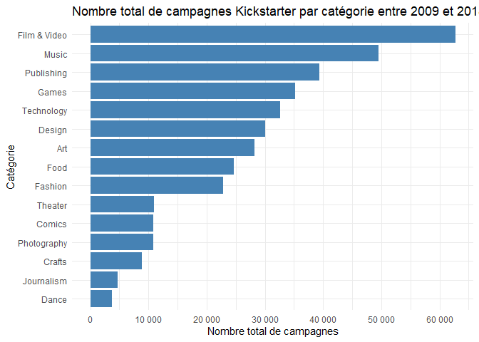

Tous les projets doivent définir un “Objectif” (`goal`), qui est la somme d’argent minimale pour que le projet soit considéré comme financé. Pendant la durée de la campagne, les utilisateurs de Kickstarter peuvent donner de l’argent au projet. La somme totale récoltée par le projet est visible dans la colonne `pledged` du dataset.

Cependant, ces valeurs monétaires sont données dans leur devise d’origine.

Pour que les comparaisons selon la devise aient plus de sens, les colonnes `usd_goal_real` et `usd_pledged_real` font la conversion des sommes en dollar étasunien (USD)

Voici les distributions des projets selon leur objectif `goal` et les sommes réellement récoltées `pledged`

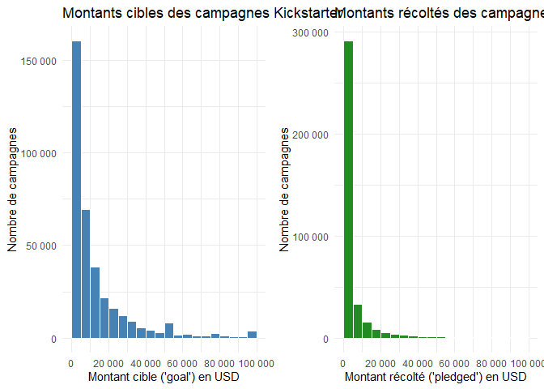

Chaque financeur est appelé un `backer`. Le dataset associe à chaque projet la quantité de personnes qui l’ont financé :

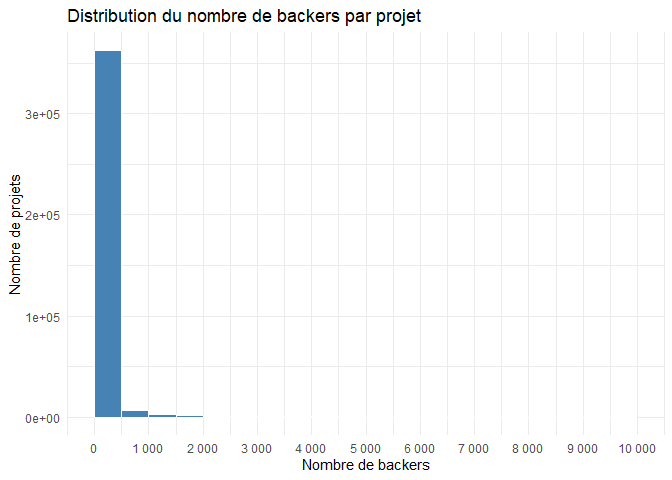

Chaque projet ne peut être financé que dans un temps imparti, situé entre le lancement de la campagne (`launched`) et sa clôture (`deadline`). Aucun financement supplémentaire n’est accepté au delà de la clôture de la campagne.

Dans les visualisations suivantes, nous allons voir la quantité de projets lancés chaque année et les durées des campagnes de notre dataset.

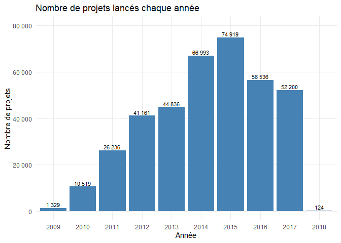

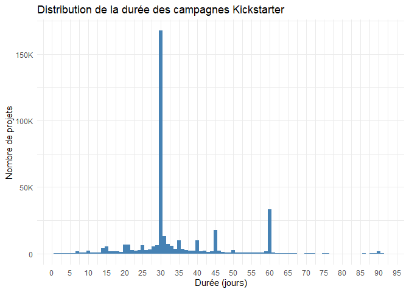

On voit également des pics sur tous les multiples de 5 jours.

### III. Analyses Exploratoires

On cherche à étudier les possibles corrélations entre le montant demandé, le montant récolté, le nombre de backers et le résultat de la campagne :

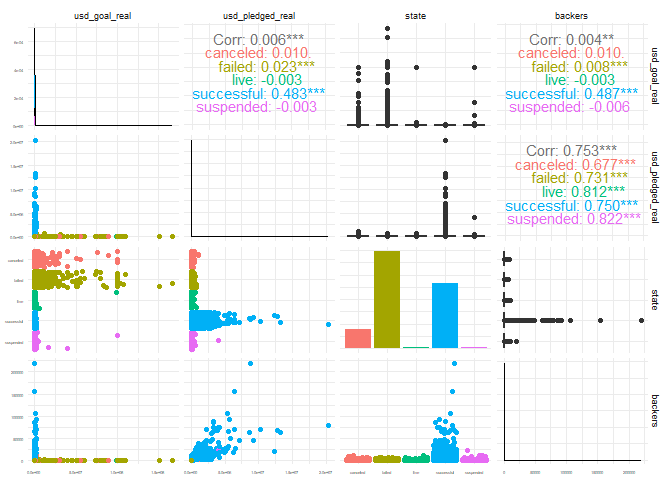

On observe déjà un phénomène intéressant :

Les projets qui demandent un montant très élevé ont tendance à échouer ou être annulé, et n’atteignent jamais le montant demandé.

A contrario, les projets qui reçoivent un montant très élevé de financement ont demandé à la base une somme beaucoup plus raisonnable.

On observe ainsi une claire dichotomie dans les graphes du côté inférieur gauche, entre des projets qui reçoivent énormément de fonds avec un objectif à la base très raisonnable, et des projets demandant un montant très élevé recevant des sommes très raisonnables et donc insuffisantes.

A noter: Cette analyse ne prend en compte que les projets dont le *goal* ou le *pledged* est relativement élevé. Or, comme on le voit dans les graphes de la diagonale, l’immense majorité des projets ont un *goal* et un *pledged* peu élevés qui les rend quasi invisible dans ce graphe.

### IV. QUESTIONS

#### QUESTION 1 : Quels sont les taux de réussite des campagnes en fonction des catégories ?

Nous allons analyser les taux de réussite des campagnes Kickstarter en fonction des catégories. Cette analyse nous permettra d’identifier les catégories qui réussissent le mieux et celles qui rencontrent plus de difficultés.

##### Nombre total de campagnes Kickstarter par catégorie

Dans un premier temps, nous allons commencer par regarder le nombre total de campagnes Kickstarter par catégorie. Cela nous permettra de voir si certaines catégories sont sur-représentées ou sous-représentées.

[figure not shown]

[figure not shown]

Cette visualisation montre que certaines catégories, comme **Film & Video** et **Music**, ont un nombre très élevé de campagnes, tandis que d’autres, comme **Dance**, en ont beaucoup moins. On observe aussi un écart significatif entre **Film & Video** et **Dance**.

##### Taux de réussite des campagnes Kickstarter par catégorie

Examinons maintenant le taux de réussite pour chaque catégorie. Pour cela, nous allons regarder le pourcentage de projets réussis dans une catégorie.

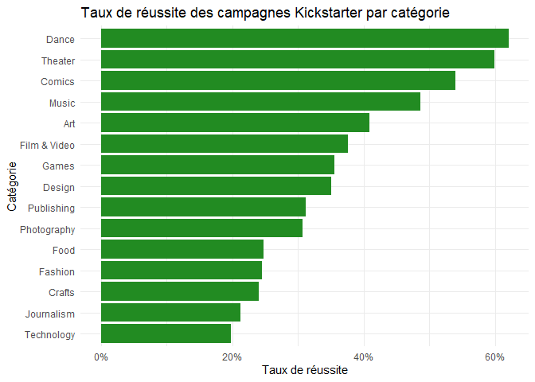

Dans cette visualisation, nous observons que les catégories **Dance**, **Theater** et **Comics** affichent les taux de réussite les plus élevés, avec notamment près de **60%** de réussite pour ces deux catégories. Cela peut s’expliquer par une communauté plus engagée ou des projets bien ciblés dans ces domaines.

En revanche, les catégories comme **Technology** et **Journalism** ont les taux de réussite les plus faibles, autour de **20%**. Cela peut être dû à des projets plus complexes avec des coûts beaucoup plus élevés.

Cela peut expliquer en partie les différences de taux de réussite : les catégories avec moins de projets peuvent avoir une communauté plus ciblée et engagée.

##### Répartition des montants demandés par catégorie

Enfin, analysons la répartition des montants demandés dans chaque catégorie possible de projets. Cela nous permettra de vérifier si certaines catégories ont des budgets aux des montants plus élevés ou plus faibles.

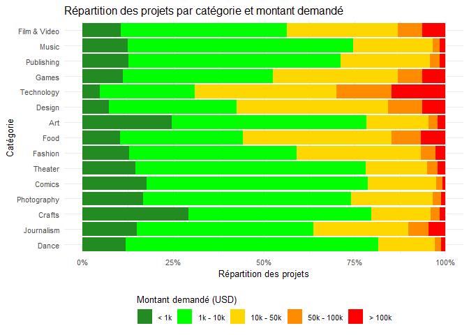

Ce graphique révèle que certaines catégories, comme **Technology**, ont une proportion plus élevée de projets demandant des montants importants (2/3 des projets à plus de 10 000 dollars). A l’inverse la catégorie **Dance** regroupe des projets de plus petits montants (80% en dessous de 10 000 dollars).

Les projets nécessitant des financements plus importants, comme ceux de la catégorie **Technology**, ont souvent des taux de réussite plus faibles car ils impliquent des besoins financiers plus lourds. À l’inverse, des catégories comme **Dance** demandent des budgets plus modestes, ce qui permet à un plus grand nombre de projets de réussir sans exiger des sommes trop importantes.

Une exception notable est la catégorie **Journalism** qui, malgré des besoins financiers modestes, embarque peu de contributeurs, ce qui peut expliquer son faible taux de réussite.

#### QUESTION 2 : Quels pays ont les meilleurs taux de réussite ?

##### Quels pays ont le plus de projets?

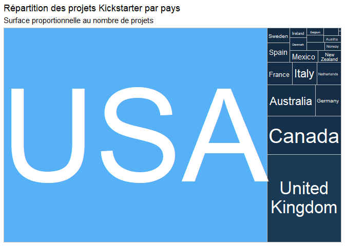

Ce graphique représente la quantité de projets lancés sur Kickstarter par pays.

On remarque une grande sur-représentation des États-Unis, pays de création de Kickstarter, dans une proportion qui ne saurait être expliquée par la seule différence de population.

On remarque ensuite une proéminence des pays anglo-saxons dans les pays dont le plus de projets sont validés.

On peut lier cela au fait que Kickstarter a été lancé progressivement dans le monde. Pour avoir une vision qui reflète mieux la popularité de Kickstarter, on pourrait comparer les quantités de projets selon le temps dans un prochain livrable. On peut également expliquer cela par le fait que, dans de nombreux pays, une offre plus locale et adaptée a eu le temps de se développer, avant l’arrivée de Kickstarter ou en parallèle.

Étudions l’évolution de la quantité de projets selon le pays pour y voir plus clair:

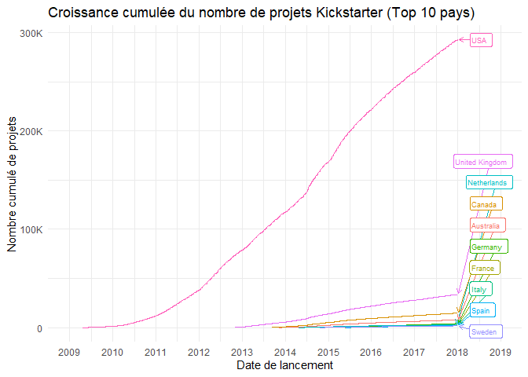

Faisons un zoom sur les autres pays du Top 10 qui ne sont pas les États-Unis :

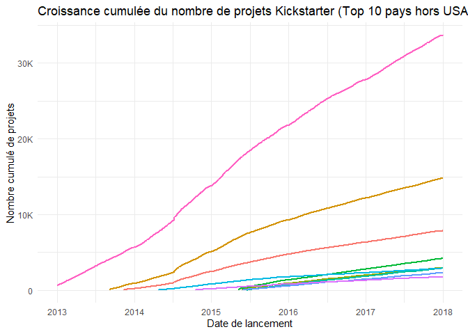

On remarque que les pays où Kickstarter arrive plus tôt ont une croissance plus forte du nombre de projets lancés.

Cela peut s’expliquer par le fait que l’implantation rapide de son service permet de se faire une meilleure place dans le marché. Passé 2014, Kickstarter s’est installé dans des pays où une offre de financement participatif concurrente s’était déjà développé avant son arrivée, ce qui n’est pas le cas aux États-Unis où le concept était novateur en 2009.

Par exemple en France, Kickstarter est rarement cité comme la meilleure plateforme de crowdfunding: https://bpifrance-creation.fr/encyclopedie/financements/financement-participatif/sites-plateformes-crowdfunding

Des services plus adaptés se sont implantés avant son arrivée.

##### Quels pays ont le meilleur taux de réussite?

On émet l’hypothèse que les pays avec le plus grand nombre de projets, où Kickstarter est le plus implanté, ont un meilleur taux de réussite.

Dans la visualisation suivante, nous allons évaluer la répartition des projets selon leur statut dans les pays du top 10.

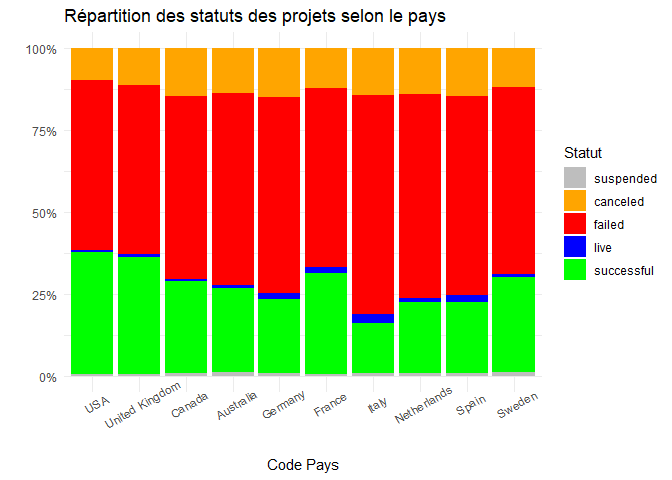

On remarque que la variation des taux de réussite n’est pas clairement corrélée à la quantité de projets lancés: près de la moitié des pays représentés dérogent à cette règle.

On émet l’hypothèse que les variations dans le taux de réussite pourraient avoir une composante géographique: Peut-être que les projets Kickstarter de certaines régions géograpphiques ont plus de succès que d’autres.

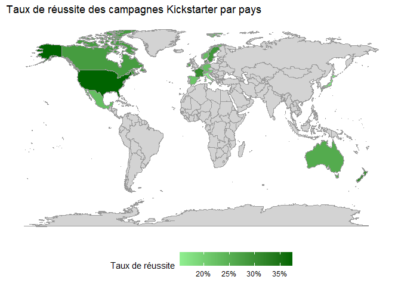

Cette carte nous permet de constater deux phénomènes:

- Kickstarter est majoritairement disponible dans des pays développés occidentaux: Amérique du nord, Europe de l’Ouest et du Nord, Australie-Nouvelle Zélande. La seule exception visible est le Japon, dont l’inclusion à Kickstarter était très récente en 2018.
- Il ne semble pas y avoir de corrélation majeure entre la zone géographique et le taux de réussite. En Europe par exemple, les pays d’Europe de l’ouest ne semblent pas favorisés.

Cette carte est utile mais a un défaut: elle ne permet pas de visualiser clairement les micro-nations comme Hong Kong ou Singapour, pourtant significatives pour Kickstarter.

Dans notre prochaine visualisation, nous allons évaluer s’il existe une corrélation entre le nombre de projets lancés dans chaque pays et leur taux de réussite:

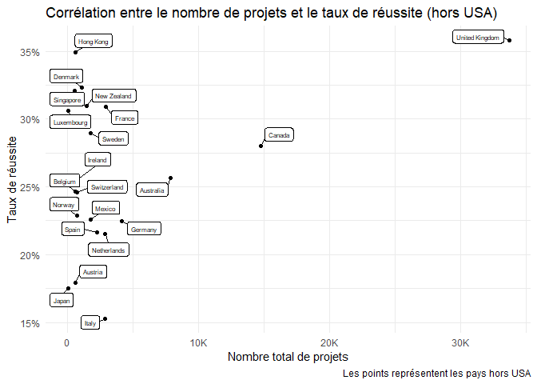

Il n’y a pas de lien clair entre la quantité de projet et le taux de réussite, la majorité des pays avec des quantités de projets très similaires ont des taux de réussites très variés.

#### QUESTION 3 : Existe-t-il des périodes de l’année où les campagnes ont plus de chances de réussir ?

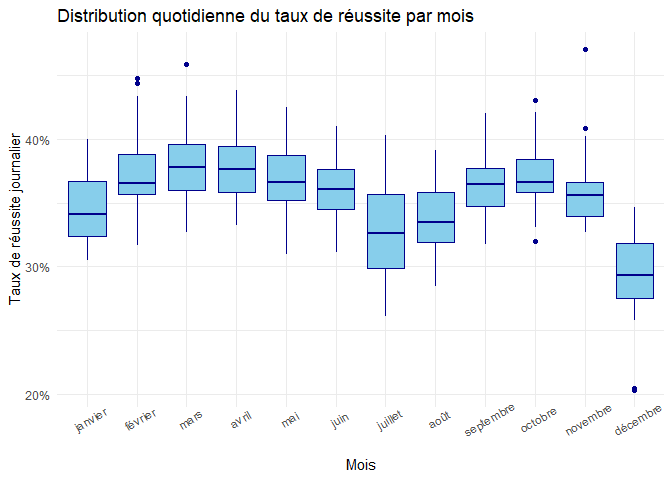

Ce graphique illustre le taux de réussite mensuel des campagnes Kickstarter selon la date de lancement. On observe que ce taux fluctue dans une plage relativement étroite, comprise entre 0,29 et 0,38. Bien que les taux de réussite semblent similaires, des tendances notables se dégagent, qui peuvent être expliquées par des facteurs contextuels.

En particulier, on remarque un **taux de réussite plus faible en décembre**, probablement en raison des périodes de fêtes. Pendant ce mois, de nombreuses personnes privilégient l’achat de cadeaux plutôt que de contribuer à des campagnes de financement participatif. Cela pourrait expliquer la baisse de l’engagement.

Par ailleurs, une tendance saisonnière apparaît durant l’été, période de vacances où les dépenses personnelles sont souvent consacrées à des loisirs, notamment les voyages. L’augmentation des coûts liés aux voyages pourrait réduire la capacité des individus à financer des projets, ce qui se traduit par une légère diminution du taux de réussite des campagnes lancées pendant cette période.

##### On peut se demander si la corrélation se poursuit au niveau de la cloture des campagnes ?

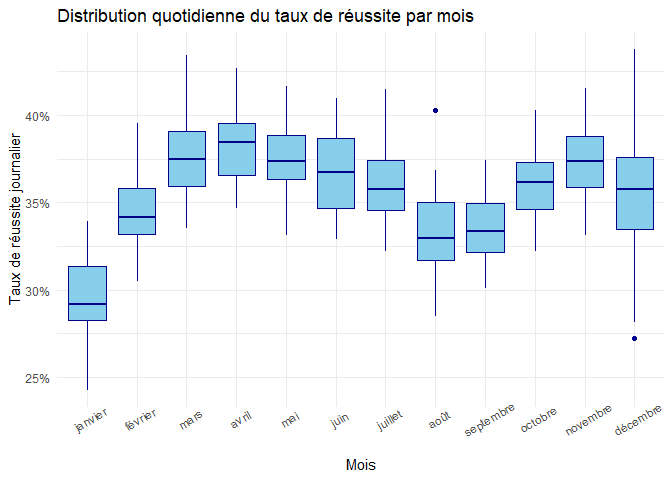

Ce graphique illustre le taux de réussite mensuel des campagnes Kickstarter en fonction de leur date de clôture. On observe que les taux sont similaires à ceux basés sur la date de lancement, mais décalés d’un mois.

##### Pour vérifier si cela est possible, il faut qu’on observe la durée des campagnes ?

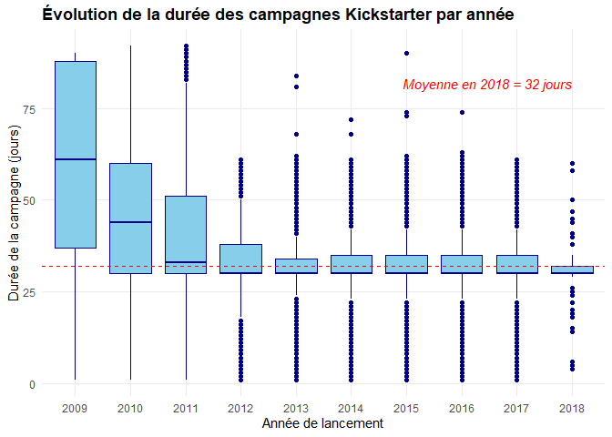

Ce graphique représente la durée des campagnes sur Kickstarter, exprimée en jours. On peut observer que la durée des campagnes diminue depuis 2009 pour passer d’environ 2 mois a 1 mois en moyenne. Cette observation confirme l’hypothèse précédemment formulée : le décalage d’un mois observé entre les taux de réussite selon que l’on se base sur la date de lancement ou sur la date de clôture s’explique par la durée moyenne des campagnes. Ainsi, d’après nos analyses, les périodes les plus favorables au succès d’un projet se situent entre février et juin, ainsi qu’entre septembre et novembre.

##### Quelle est la durée idéale d’une campagne ?

Comme nous l’avons vu précédemment, la majorité des campagnes durent 30 jours. C’est la valeur par défaut de la durée dans l’interface de création de campagne, où il est aussi affirmé que les campagnes de moins de 30 jours ont plus de chances de réussir. Est-ce vrai?

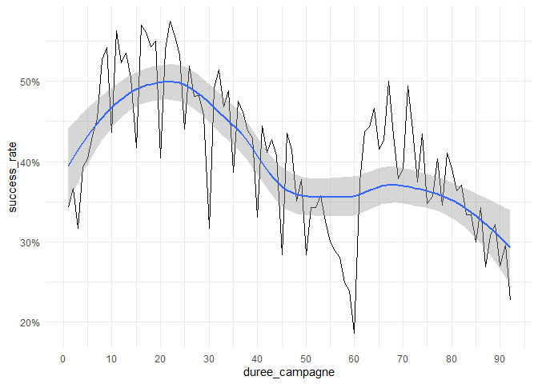

On peut observer qu’une campagne inférieur a 40 jours à un taux de réussite de 40% à 50% alors qu’ensuite, le taux chute jusqu’à 30%. On en déduis donc qu’une durée idéale de campagne est de 20 à 25 jours avec un taux de réussite à 50%.

#### QUESTION 4 : Comment les montants demandés et récoltés ont-ils évolué au cours du temps ?

##### Evolution brute des montants

Dans cette partie, nous nous intérresserons à l’évolution des montants demandés et récoltés par les campagnes kickstarter selon les époques.

Tout d’abord, nous allons représenter le montant moyen demandé selon l’année

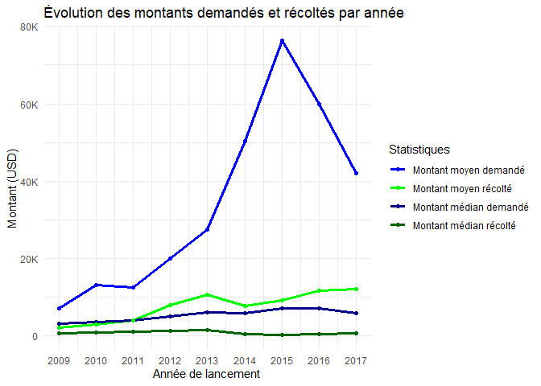

##### Quels sont les pourcentages de complétion des campagnes réussies?

Nous allons étudier l’évolution des pourcentages de complétion des projets réussis

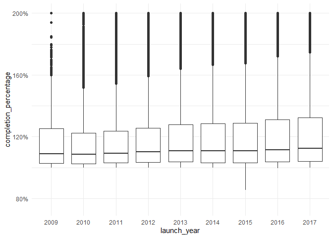

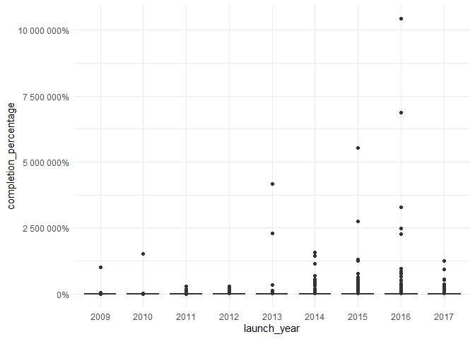

On remarque que l’immense majorité des projets réussis dépassent de peu leur objectif, et ce peu importe l’époque.

On remarque cependant qu’au fil des années de plus en plus de projets pulvérisent leur objectif, et dans des proportions de plus en plus grandes

#### QUESTION 5 : Le choix des mots dans le titre d’une campagne a-t-il un impact sur son succès ?

##### La longueur du titre influence-t-elle le taux de succès d’une campagne ?

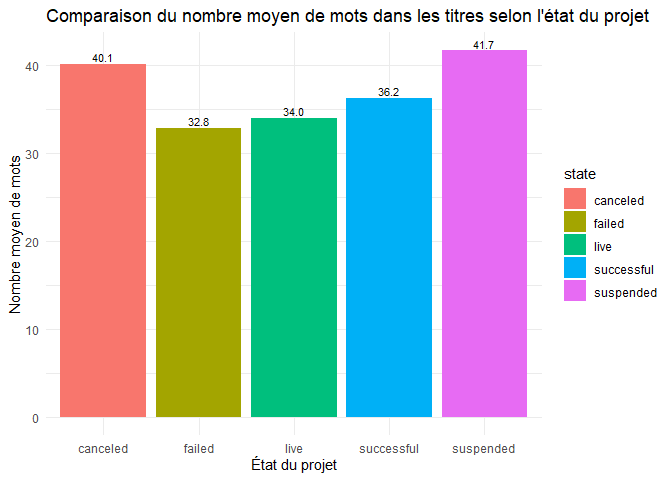

##### Certains mots dans le titre sont-ils plus fréquents dans les campagnes réussies que dans les campagnes échouées ?

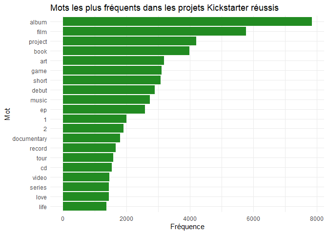

Qu’en est il pour les campagnes non réussie ?

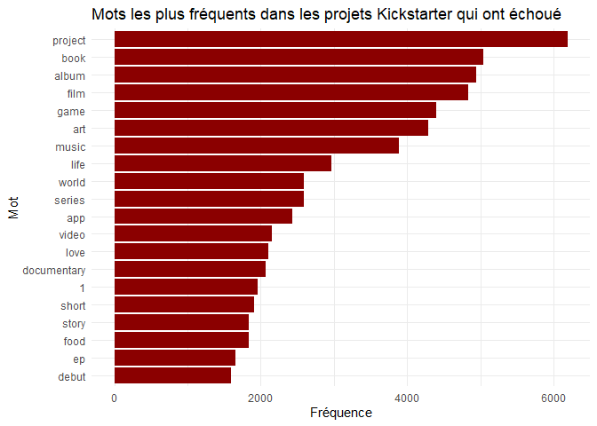

On s’aperçoit rapidement que les mots les plus utilisés n’ont pas de lien avec la réussite ou non d’un projet mais plutôt avec les catégories les plus représentés, biaisant ainsi l’analyse des mots fréquents dans les titres.

Pour corriger ce biais, nous allons normaliser la fréquence des mots en tenant compte de la proportion de chaque catégorie, en multipliant la fréquence brute d’un mot par l’inverse de la proportion de sa catégorie.

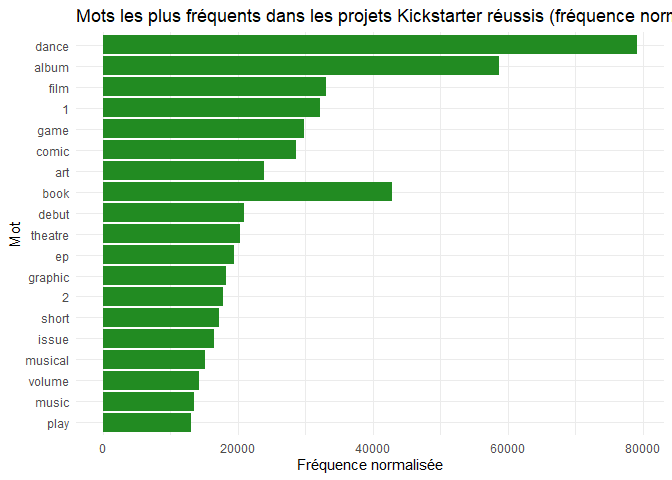

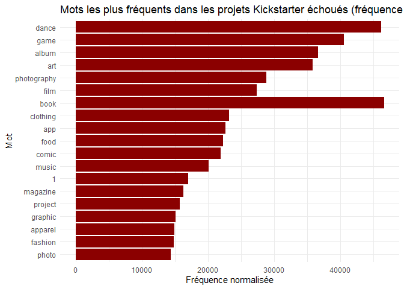